# An Introduction to PurpleAir Synoptic Data

Mazama Science

2019-04-19

*Synoptic data* provides a synopsis - a comprehensive and nearly instantaneous picture of the state of the atmosphere. This vignette demonstrates an example workflow for exploring air quality synoptic data using the AirSensor R package and data captured by [PurpleAir](https://www.purpleair.com/) air quality sensors.

### Loading PurpleAir Data

PurpleAir sensor readings are uploaded to the cloud every 80 seconds or so where they are stored for download and display on the PurpleAir website. In order to capture and download the latest synoptic dataset, begin by importing the required Mazama Science packages, setting the location of pre-generated archive files and loading the most recent PurpleAir Synoptic (“`pas`”) data.

```r
library(AirSensor)
library(dplyr)
library(ggplot2)

setArchiveBaseUrl("http://smoke.mazamascience.com/data/PurpleAir")

pas <- pas_load()
```

The `pas_load()` function is a wrapper function that will:

1. Download a raw dataset of the entire PurpleAir network that includes both metadata and recent PM2.5 averages for each deployed sensor across the globe. See `downloadParseSynopticData()` for more info.
2. Enhance the raw dataset by replacing variables with more consistent and human readable names, adds spatial metadata for each sensor, and lists the nearest official air quality monitor. For a more in depth explanation, see `enhanceSynopticData()`.

### PurpleAir Synoptic Data

The `pas` dataset contains 35 columns, and each row corresponds to different PurpleAir sensors. For the scope of this example we will focus on the columns labeled `stateCode`, `pm25_*`, `humidity`, `pressure`, `temperature`, and `pwfsl_closestDistance`.

The `pm25_*` column is short-hand for all the columns containing PM2.5 data. The extended names are fairly obvious; the `pm25_current` column contains data for the most recent air data, `pm25_10min` contains a 10-minute average of PM2.5 data, and so on.

```r
pas %>%
  select(starts_with("pm25_")) %>%
  head(5)
```

```
## # A tibble: 5 x 7
##   pm25_current pm25_10min pm25_30min pm25_1hr pm25_6hr pm25_1day pm25_1week
##          <dbl>      <dbl>      <dbl>    <dbl>    <dbl>     <dbl>      <dbl>
## 1         8.99       8.81       8.39     7.92     7.11      6.69       4.19
## 2         9.66       9.22       8.78     8.3      7.51      7.08       4.46
## 3         9          9.29       9.45     9.32     9.5       8.84       6.15
## 4         3.89       4.72       4.78     4.62     4.74      4.47       3.15
## 5         8.24       8.12       7.89     7.51     7.31      7.27       4.82
```

### Mapping `pas` PM2.5 data

To visually explore a region, we can use our `pas` data with the `pas_leaflet()` function to plot an interactive [leaflet](https://leafletjs.com/) map. By default, `pas_leaflet()` will map the coordinates of each PurpleAir sensor and the hourly PM2.5 data. Clicking on a sensor will show sensor metadata.

```r
pas %>%
  pas_leaflet()
```

[interactive chart not shown]

If we want to narrow our selection, for example to California, and look at which locations have a moderate to unhealthy 6-hour average air quality rating we can create a script like:

```r
pas %>%
  filter(stateCode == 'CA') %>%
  filter(pm25_6hr >= 25.0) %>%
  pas_leaflet(parameter = "pm25_6hr")
```

[interactive chart not shown]

This code pipes our `pas` data into `dplyr::filter()` where we can set our selection criteria. A `stateCode` is the ISO 3166-2 state name abbreviation, hence we limit our filter to only accept `stateCode == 'CA'`. The `pm25_6hr` selection, as mentioned above, selects the 6-hour average and restricts the sensors to those whose PM2.5 6-hour average is above 25.0. Be sure to include the `"pm25_6hr"` parameter in `pas_leaflet()`.

### Mapping `pas` auxillary data

We can also explore and utilize other PurpleAir sensor data. Check the `pas_leaflet()` documentation for all supported parameters.

Here is an example of humidity data captured from PurpleAir sensors across the state of California.

```r
pas %>%
  filter(stateCode == "CA") %>%
  pas_leaflet(parameter = "humidity")
```

[interactive chart not shown]

### Exploring PurpleAir data

Because the `pas` object is a dataframe, we can use functionality from the **dplyr** package to manipulate the data.

Below, we show how to find out which states have the highest *percentage* of PurpleAir sensors that are reporting a weekly average of >20 ug/m3.

```r
sensorCount <-
  pas %>%
  count(stateCode, name="sensorCount", sort = TRUE)

gt20Count <-
  pas %>%
  select(stateCode, pm25_1week) %>%
  filter(pm25_1week > 20.0) %>%
  count(stateCode, sort = TRUE, name = "gt20Count")

df <-
  left_join(gt20Count, sensorCount, by = "stateCode") %>%
  mutate(gt20Fraction = gt20Count / sensorCount) %>%
  arrange(desc(gt20Fraction)) %>%
  top_n(15)
```

From our `df` data frame, we can use `ggplot2` to visualize our results.

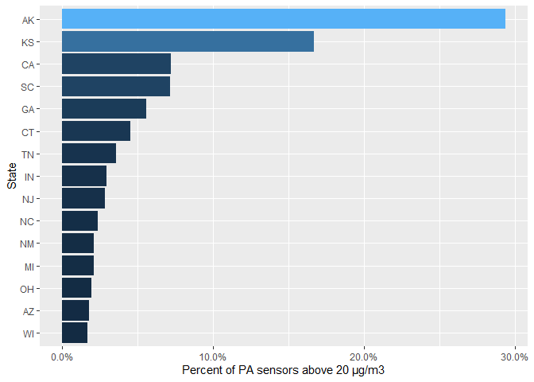

```r
df %>%
  ggplot(aes(x = reorder(stateCode, gt20Fraction), y = gt20Fraction)) +
  coord_flip() +
  geom_col(aes(fill = gt20Fraction)) +
  scale_y_continuous(labels = scales::percent) +
  labs(x = "State", y = "Percent of PA sensors above 20 \u00B5g/m3") +
  theme(legend.position = "none")
```

As you can see, the AirSensor package combined with data provided by PurpleAir offers a powerful system for regional air-quality assessment.

*Mazama Science*